# Keras

남원식

**Keras Package 내 Boston Housing Price 데이터셋과 함수를 이용하여 다중 회귀분석을 수행하시오**  
**Bouston Housing Pirce 데이터 셋에 대한 설명**

1. CRIM 자치시(town) 별 1인당 범죄율
2. ZN 25,000 평방피트를 초과하는 거주지역의 비율
3. INDUS 비소매상업지역이 점유하고 있는 토지의 비율
4. CHAS 찰스강에 대한 더미변수(강의 경계에 위치한 경우는 1, 아니면 0)
5. NOX 10ppm 당 농축 일산화질소
6. RM 주택 1가구당 평균 방의 개수
7. AGE 1940년 이전에 건축된 소유주택의 비율
8. DIS 5개의 보스턴 직업센터까지의 접근성 지수
9. RAD 방사형 도로까지의 접근성 지수
10. TAX 10,000 달러 당 재산세율
11. 0PTRATIO 자치시(town)별 학생/교사 비율
12. BK 흑인의 비율
13. LSTAT 모집단의 하위계층의 비율(%)
14. MEDV 본인 소유의 주택가격(중앙값) (단위: $1,000)

**데이터 전처리 과정**  
`- 데이터 로드 및 분할`

**설명**

boston_housing 데이터셋을 로드한후 train set,test으로 분할한다.

```
import keras
(X_train, Y_train), (x_test, y_test) = boston_housing.load_data()
```

`- 데이터의 정규화`

**설명**

데이터의 범위가 너무 광범위하기때문에 데이터를 정규화 해준다.

[output not shown]

**Keras를 이용하여 다중회귀모델 생성하기**

`-순차모델 생성하기`

**설명**

Keras패키지의 Sequential 메서드를 이용하여 모델을 생성해준다.

```
model = keras.Sequential([
    keras.layers.Dense(units=50, activation='relu', input_shape=(13,)),
    keras.layers.Dense(units=30, activation='relu'),
    keras.layers.Dense(units=20, activation='relu'),
    keras.layers.Dense(units=1)])
```

`-모델 컴파일하기`

**설명**

adam = 가중치와 절편을 추정하여 실제값과 유사한 값을 찾아준다.

[output not shown]

`-모델 학습시키기`

```
m1_fit = model.fit(X_train, Y_train, epochs=25, batch_size=32, validation_split=0.25)
```

`-머신러닝 성능 평가하기`

```
model.evaluate(x_test, y_test)
```

`-예측한 값을 시각화하기`

[output not shown]

`-실제값과 예측값과 비교하기`

[output not shown]

**keras package 내 Boston Housing Price 데이터셋 대상으로 기존의 R 함수를 이용하여 다중회귀분석을 실행하고 (1)번의 결과와 비교하시오**

```r
library(mlbench)
library(car)
data("BostonHousing")
formula <- medv ~ crim + zn + indus + chas + nox + rm + age + dis + rad +
  tax + ptratio + b + lstat
lm_boston <- lm(formula, data = BostonHousing)
lm2_boston <- step(lm_boston, direction="both")
```

```
## Start:  AIC=1589.64
## medv ~ crim + zn + indus + chas + nox + rm + age + dis + rad +
##     tax + ptratio + b + lstat
##
##           Df Sum of Sq   RSS    AIC
## - age      1      0.06 11079 1587.7
## - indus    1      2.52 11081 1587.8
## <none>                 11079 1589.6
## - chas     1    218.97 11298 1597.5
## - tax      1    242.26 11321 1598.6
## - crim     1    243.22 11322 1598.6
## - zn       1    257.49 11336 1599.3
## - b        1    270.63 11349 1599.8
## - rad      1    479.15 11558 1609.1
## - nox      1    487.16 11566 1609.4
## - ptratio  1   1194.23 12273 1639.4
## - dis      1   1232.41 12311 1641.0
## - rm       1   1871.32 12950 1666.6
## - lstat    1   2410.84 13490 1687.3
##
## Step:  AIC=1587.65
## medv ~ crim + zn + indus + chas + nox + rm + dis + rad + tax +
##     ptratio + b + lstat
##
##           Df Sum of Sq   RSS    AIC
## - indus    1      2.52 11081 1585.8
## <none>                 11079 1587.7
## + age      1      0.06 11079 1589.6
## - chas     1    219.91 11299 1595.6
## - tax      1    242.24 11321 1596.6
## - crim     1    243.20 11322 1596.6
## - zn       1    260.32 11339 1597.4
## - b        1    272.26 11351 1597.9
## - rad      1    481.09 11560 1607.2
## - nox      1    520.87 11600 1608.9
## - ptratio  1   1200.23 12279 1637.7
## - dis      1   1352.26 12431 1643.9
## - rm       1   1959.55 13038 1668.0
## - lstat    1   2718.88 13798 1696.7
##
## Step:  AIC=1585.76
## medv ~ crim + zn + chas + nox + rm + dis + rad + tax + ptratio +
##     b + lstat
##
##           Df Sum of Sq   RSS    AIC
## <none>                 11081 1585.8
## + indus    1      2.52 11079 1587.7
## + age      1      0.06 11081 1587.8
## - chas     1    227.21 11309 1594.0
## - crim     1    245.37 11327 1594.8
## - zn       1    257.82 11339 1595.4
## - b        1    270.82 11352 1596.0
## - tax      1    273.62 11355 1596.1
## - rad      1    500.92 11582 1606.1
## - nox      1    541.91 11623 1607.9
## - ptratio  1   1206.45 12288 1636.0
## - dis      1   1448.94 12530 1645.9
## - rm       1   1963.66 13045 1666.3
## - lstat    1   2723.48 13805 1695.0
```

**설명**

AIC는 아카이케 정보기준을 나타내며 품질을 나타낸다. AIC가 낮을수록 좋은 포뮬러이다.

`-최적의 포물러 찾기`

```r
formula2 <- medv ~ crim + zn + chas + nox + rm + dis + rad + tax + ptratio +
  b + lstat
lm3_boston <- lm(formula2, data = BostonHousing)
lm3_boston
```

```
##
## Call:
## lm(formula = formula2, data = BostonHousing)
##
## Coefficients:
## (Intercept)         crim           zn        chas1          nox           rm
##   36.341145    -0.108413     0.045845     2.718716   -17.376023     3.801579
##         dis          rad          tax      ptratio            b        lstat
##   -1.492711     0.299608    -0.011778    -0.946525     0.009291    -0.522553
```

```r
summary(lm3_boston)
```

```
##
## Call:
## lm(formula = formula2, data = BostonHousing)
##
## Residuals:
##      Min       1Q   Median       3Q      Max
## -15.5984  -2.7386  -0.5046   1.7273  26.2373
##
## Coefficients:
##               Estimate Std. Error t value Pr(>|t|)
## (Intercept)  36.341145   5.067492   7.171 2.73e-12 ***
## crim         -0.108413   0.032779  -3.307 0.001010 **
## zn            0.045845   0.013523   3.390 0.000754 ***
## chas1         2.718716   0.854240   3.183 0.001551 **
## nox         -17.376023   3.535243  -4.915 1.21e-06 ***
## rm            3.801579   0.406316   9.356  < 2e-16 ***
## dis          -1.492711   0.185731  -8.037 6.84e-15 ***
## rad           0.299608   0.063402   4.726 3.00e-06 ***
## tax          -0.011778   0.003372  -3.493 0.000521 ***
## ptratio      -0.946525   0.129066  -7.334 9.24e-13 ***
## b             0.009291   0.002674   3.475 0.000557 ***
## lstat        -0.522553   0.047424 -11.019  < 2e-16 ***
## ---
## Signif. codes:  0 '***' 0.001 '**' 0.01 '*' 0.05 '.' 0.1 ' ' 1
##
## Residual standard error: 4.736 on 494 degrees of freedom
## Multiple R-squared:  0.7406, Adjusted R-squared:  0.7348
## F-statistic: 128.2 on 11 and 494 DF,  p-value: < 2.2e-16
```

**설명**

최적의 포뮬러를 찾은후 회귀분석 보기

`-트레이닝셋과 테스트셋 나누기`

```r
idx = sample(1:nrow(BostonHousing), 0.7*nrow(BostonHousing))
idx
```

```
##   [1]  32  46 441 373 427 258 450 115 124 200 268 142 317  54 280  39 151 432
##  [19] 480 233  28  93  75  26  20 485 174 157 263 428 246 304  17  15 152 215
##  [37] 276 139 306   6 439 109 438 121 123 180  34 367  27  30  40 281 375 447
##  [55]  89 467 226 326 464 394  63 407 391 197 398 505 199 433 478 386 308 171
##  [73]  25 107 223   1  84 221 425  92 443 277 213 176 214 362 273 162 383 218
##  [91] 127 345 283 412 172  60 337  97 496 331 133 363 105  55 217 275 243 333
## [109] 498 364  71 315 444 279 350 422 104 487 365 406 486 459 404 352  12 129
## [127] 339 356 429 494 106 387 187 369 477  59  14  19  16 354  45 244 295 259
## [145]  33 132 307 416 140 241 495  38 204 145 160 175 289 255 327 497  65 103
## [163] 372 340 274  21  52 198  64 482 186 242 202 502 335  91 491 231 358 212
## [181] 409 196  41 205 131 284   7 321 382 504  70  48 285  24 300 117  80 435
## [199] 193 499  23 208 341 440 112 479 452 298  58 319 148 110 389 343 251 346
## [217] 377 401 442 310  82  76 130 392 449  37 355 500 302 393 146 290 413  87
## [235]  42 254 191 282 265  95 311 309  11 336 136 492 165 150 143 245 503 475
## [253] 347 118 325 457 436 261 348  51 114 476 322 182 210   3 385 357 100 360
## [271] 250 493 296   9 189 420 419 126   8 448 423 116 314  86 451  22 312 453
## [289] 240 374 488 239 506 141  77 177 465  36 379 474 403 421 164 460 297 330
## [307] 455  96  49  66 234 156 195 299 328 334  81 294 463 458  74 248 378 163
## [325] 359 472 466 376 194 108 370 405 291 170 185 430 184 320 316 201 397  35
## [343] 113 173  90 220 207 147  43 361 153 342 388  83
```

```r
train <- BostonHousing[idx,]
test <-  BostonHousing[-idx,]
```

`-학습하고 예측하기`

```r
set.seed(1234)
fit.lm <- lm(formula, data = train)
summary(fit.lm)
```

```
##
## Call:
## lm(formula = formula, data = train)
##
## Residuals:
##      Min       1Q   Median       3Q      Max
## -15.9522  -2.7030  -0.5426   1.5498  27.7435
##
## Coefficients:
##               Estimate Std. Error t value Pr(>|t|)
## (Intercept)  33.999758   6.562445   5.181 3.79e-07 ***
## crim         -0.128293   0.047172  -2.720 0.006871 **
## zn            0.052594   0.017164   3.064 0.002357 **
## indus         0.010306   0.076229   0.135 0.892536
## chas1         3.534004   1.086353   3.253 0.001256 **
## nox         -17.539367   4.645723  -3.775 0.000189 ***
## rm            4.009135   0.544647   7.361 1.39e-12 ***
## age          -0.003999   0.016475  -0.243 0.808365
## dis          -1.441860   0.240562  -5.994 5.23e-09 ***
## rad           0.331747   0.082890   4.002 7.71e-05 ***
## tax          -0.013485   0.004681  -2.881 0.004222 **
## ptratio      -0.972054   0.159858  -6.081 3.22e-09 ***
## b             0.011251   0.003339   3.369 0.000840 ***
## lstat        -0.432128   0.063687  -6.785 5.16e-11 ***
## ---
## Signif. codes:  0 '***' 0.001 '**' 0.01 '*' 0.05 '.' 0.1 ' ' 1
##
## Residual standard error: 4.91 on 340 degrees of freedom
## Multiple R-squared:  0.7265, Adjusted R-squared:  0.7161
## F-statistic: 69.49 on 13 and 340 DF,  p-value: < 2.2e-16
```

```r
pred.lm <- predict(fit.lm, test)
cor(pred.lm,test$medv)
```

```
## [1] 0.873171
```

**설명**

[figure not shown]

**설명**

```
import os
import shutil
from keras import layers
from keras import models
from keras import optimizers
from keras.preprocessing.image import ImageDataGenerator
import matplotlib.pyplot as plt
```

`-조건에 제시된 사진을 저장하기위한 디렉터리 만들기`

```
train_dir = os.path.join(base_dir, 'train')
os.makedirs(train_dir,exist_ok = True)
validation_dir = os.path.join(base_dir, 'validation')
os.makedirs(validation_dir, exist_ok = True)
test_dir = os.path.join(base_dir, 'test')
os.makedirs(test_dir, exist_ok = True)
# 훈련용 고양이 사진 디렉터리 만들기
train_cats_dir = os.path.join(train_dir, 'cats')
os.makedirs(train_cats_dir, exist_ok = True)
# 훈련용 강아지 사진 디렉터리 만들기
train_dogs_dir = os.path.join(train_dir, 'dogs')
os.makedirs(train_dogs_dir, exist_ok= True)
# 검증용 고양이 사진 디렉터리 만들기
validation_cats_dir = os.path.join(validation_dir, 'cats')
os.makedirs(validation_cats_dir, exist_ok = True)
# 검증용 강아지 사진 디렉터리 만들기
validation_dogs_dir = os.path.join(validation_dir, 'dogs')
os.makedirs(validation_dogs_dir, exist_ok= True)
# 테스트용 고양이 사진 디렉터리 만들기
test_cats_dir = os.path.join(test_dir, 'cats')
os.makedirs(test_cats_dir,exist_ok = True)
# 테스트용 강아지 사진 디렉터리 만들기
test_dogs_dir = os.path.join(test_dir, 'dogs')
os.makedirs(test_dogs_dir, exist_ok = True)
```

`-조건에 따라 데이터셋 분류하기`

```
# 2000~3000번째 고양이 이미지를 train_cats_dir에 복사
fnames = ['{}.jpg'.format(i) for i in range(2000,3000)]
for fname in fnames:
    src = os.path.join(original_dataset_dir_cats, fname)
    dst = os.path.join(train_cats_dir, fname)
    shutil.copyfile(src, dst)
# 3000~ 3500번째 고양이 이미지를 validation_cats_dir에 복사
fnames = ['{}.jpg'.format(i) for i in range(3000, 3500)]
for fname in fnames:
    src = os.path.join(original_dataset_dir_cats, fname)
    dst = os.path.join(validation_cats_dir, fname)
    shutil.copyfile(src, dst)

# 3500~4000 번째 고양이 이미지를 test_cats_dir에 복사
fnames = ['{}.jpg'.format(i) for i in range(3500, 4000)]
for fname in fnames:
    src = os.path.join(original_dataset_dir_cats, fname)
    dst = os.path.join(test_cats_dir, fname)
    shutil.copyfile(src, dst)
# 4000~5000번째 강아지 이미지를 train_dogs_dir에 복사
fnames = ['{}.jpg'.format(i) for i in range(4000,5000)]
for fname in fnames:
    src = os.path.join(original_dataset_dir_dogs, fname)
    dst = os.path.join(train_dogs_dir, fname)
    shutil.copyfile(src, dst)

# 5000~5500번째 강아지 이미지를 validation_dogs_dir에 복사
fnames = ['{}.jpg'.format(i) for i in range(5000, 5500)]
for fname in fnames:
    src = os.path.join(original_dataset_dir_dogs, fname)
    dst = os.path.join(validation_dogs_dir, fname)
    shutil.copyfile(src, dst)

# 5500~6000번째 강아지 이미지를 test_dogs_dir에 복사
fnames = ['{}.jpg'.format(i) for i in range(5500, 6000)]
for fname in fnames:
    src = os.path.join(original_dataset_dir_dogs, fname)
    dst = os.path.join(test_dogs_dir, fname)
    shutil.copyfile(src, dst)
```

`-네트워크 생성하기`

```
model = models.Sequential()
model.add(layers.Conv2D(32, (3, 3), activation='relu',input_shape=(150, 150, 3)))
model.add(layers.MaxPooling2D((2, 2)))
model.add(layers.Conv2D(64, (3, 3), activation='relu'))
model.add(layers.MaxPooling2D((2, 2)))
model.add(layers.Conv2D(128, (3, 3), activation='relu'))
model.add(layers.MaxPooling2D((2, 2)))
model.add(layers.Conv2D(128, (3, 3), activation='relu'))
model.add(layers.MaxPooling2D((2, 2)))
model.add(layers.Flatten())
model.add(layers.Dense(512, activation='relu'))
model.add(layers.Dense(1, activation='sigmoid'))
model.summary()
```

**설명**

`-컴파일 하기`

```
model.compile(loss='binary_crossentropy',
              optimizer=optimizers.RMSprop(lr=1e-4),
              metrics=['acc'])
```

**설명**

네트워크의 마지막단계가 시그모이드 이기때문에 이진 크로스엔트로피를 손실로 사용함.

`-케라스 패키지를 이용하여 이미지 전처리하기`

```
train_data = ImageDataGenerator(rescale=1./255)
test_data = ImageDataGenerator(rescale=1./255)
```

`-데이터 전처리 하기`

```
# 트레이닝셋 데이터 전처리
train_generator = train_data.flow_from_directory(
        train_dir,
        target_size=(150, 150),
        batch_size=20,
        class_mode='binary')
# 150 * 150 사이즈로, 손실법을 이진으로 하기때문에 이진분류가필요함.
# 검증셋 이미지 전처리
validation_generator = test_data.flow_from_directory(
        validation_dir,
        target_size=(150, 150),
        batch_size=20,
        class_mode='binary')
```

`-트레이닝`

```
model_f = model.fit_generator(
        train_generator,
        steps_per_epoch=100,
        epochs=30,
        validation_data=validation_generator,
        validation_steps=50)
```

**설명**

에포크당 100번 30번 반복하는 네트워크이다

`-훈련데이터, 검증데이터의 손실도와 정확도를 그래프로 시각화`

```
acc = model_f.history['acc']
val_acc = model_f.history['val_acc']
loss = model_f.history['loss']
val_loss = model_f.history['val_loss']

epochs = range(len(acc))

plt.plot(epochs, acc, 'bo', label='Training acc')
plt.plot(epochs, val_acc, 'b', label='Validation acc')
plt.title('Training and validation accuracy')
plt.legend()

plt.figure()
plt.plot(epochs, loss, 'bo', label='Training loss')
plt.plot(epochs, val_loss, 'b', label='Validation loss')
plt.title('Training and validation loss')
plt.legend()
plt.show()
```

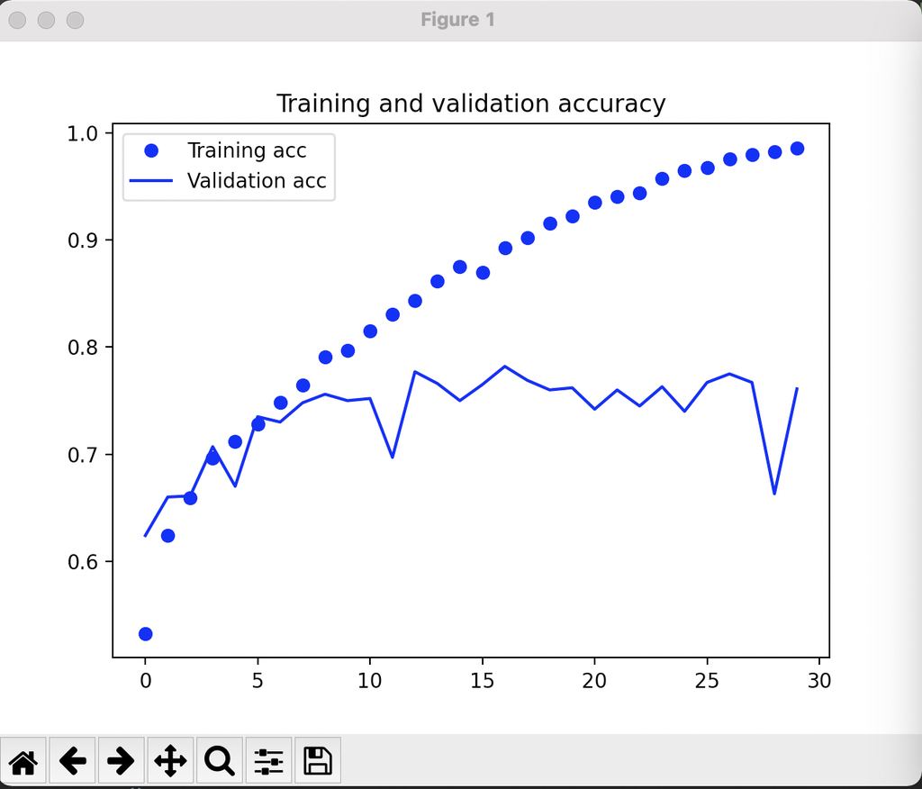

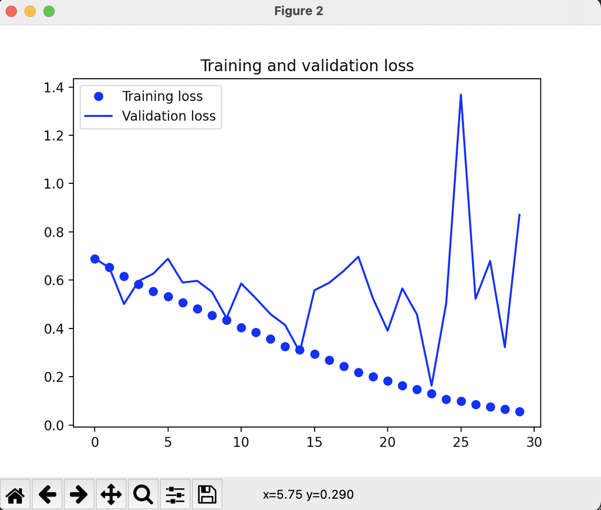

**설명**

데이터의 샘플수가 2000개 밖에 되지않아 오버피팅 현상이 일어나는 것을 볼수 있다. 데이터의 양을 늘려야 한다는 판단을 함

**2) 정확성을 높이기 위한 방법과 사용자가 조정할수 있는 파라미터는 무엇인지 기술하시오.**  
`-데이터를 증식시켜 샘플을 수를 늘리기`

[output not shown]

**설명**

rotation_range = 사진을 회전시킴  
width_shift_range와 height_shift_range는 사진을 수평과 수직으로 랜덤하게 평행 이동시킬 범위의 비율  
share range = 랜덤하게 전단 변환을 할 각도  
zoom range = 랜덤하게 화면을 확대할 범위  
horizen_flip = 랜덤하게 이미지를 수평으로 뒤집음  
fill mode = 회전이나, 가로세로 이동으로인해 픽셀을 채워야하는경우

`-증식된 데이터를 활용하여 다시 트레이닝`

```
model_f2 = model.fit_generator(
      train_generator,
      steps_per_epoch=100,
      epochs=100,
      validation_data=validation_generator,
      validation_steps=50)
```

**설명**

반복횟수를 늘려 트레이닝의 성능을 향상시킬수 있음

`-성능이 향상됬는지 확인을 위해 시각화`

```
acc = model_f2.history['acc']
val_acc = model_f2.history['val_acc']
loss = model_f2.history['loss']
val_loss = model_f2.history['val_loss']

epochs = range(len(acc))

plt.plot(epochs, acc, 'bo', label='Training acc')
plt.plot(epochs, val_acc, 'b', label='Validation acc')
plt.title('Training and validation accuracy')
plt.legend()

plt.figure()

plt.plot(epochs, loss, 'bo', label='Training loss')
plt.plot(epochs, val_loss, 'b', label='Validation loss')
plt.title('Training and validation loss')
plt.legend()

plt.show()
```

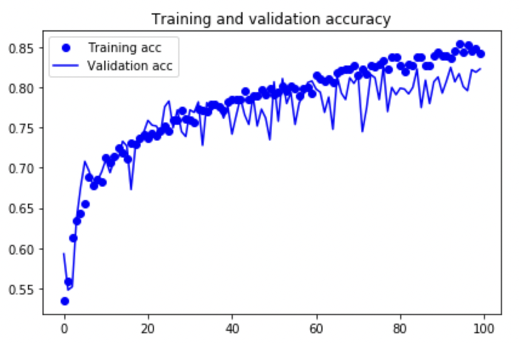

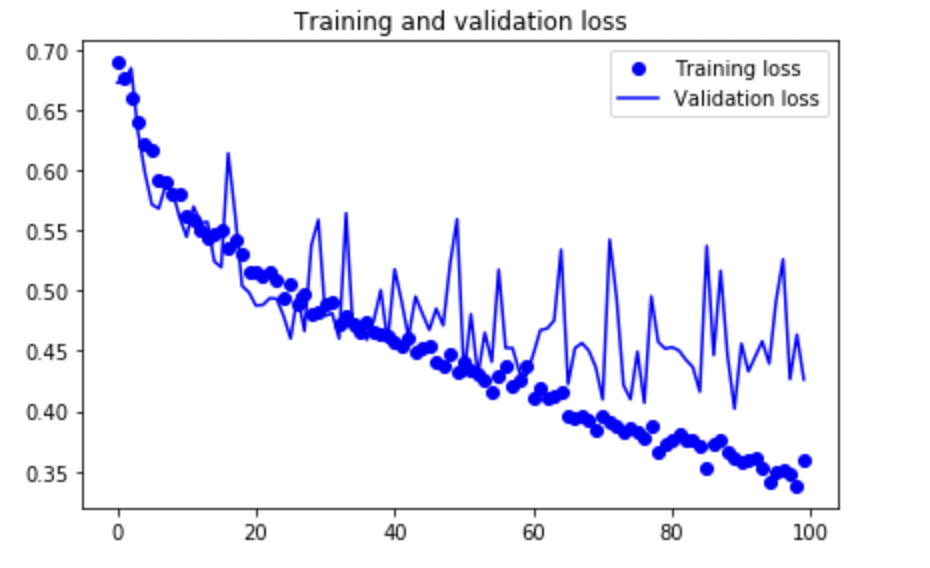

**설명**

샘플의 양을 늘리고 에포크를 더많이 반복 한결과 검증데이터의 정확도가 82퍼센트까지 증가한것을 볼수 있다.